# Machine Learning Foundation Nanodegree

<hr style = "border-width: 5px"/>

## Project 3 - Investigate a Dataset

### Author: Vishwajit Bhadrashetty

### **Abstract**

We will be investigating and analyzing the Titanic dataset provided by the <a style = "text-decoration: none" href = "https://www.kaggle.com/c/titanic/data" >Kaggle</a> website. All data resides in *titanic-data.csv*. We will use the standard procedure of data analysis while investigating the data. As per the data analysis process five phases are utilized in investigating the data:

1. Questioning.
2. Data Wrangling.
3. Exploration.
4. Conclusion.
5. Communication. (**Implicit within **Revivsiting the Questions, Exploration** and **Conclusion** phase.**)

The five steps are not linear but revisited when required in order to refine the analysis process.We will use Python language to process the data. Almost all of the source code is **PEP-8** compliant.

<hr style = "border-width: 5px"/>

### Import all the required modules and set up the plot style

```python
# These modules are required in order to use built-in arrays,
# series and DataFrame data structures.
import numpy as np
import pandas as pd
import scipy

# Following imports help us in showing different types of plots.
import matplotlib.pyplot as plt
import seaborn as sns
sns.set(style="whitegrid", color_codes=True)

# Thid method is used to display float values
# to a precision of two decimal places.
def float_formatter(x):
    return "%.2f" % x
```

<hr style = "border-width: 5px"/>

### Read and display sample statistics of titanic data

```python
titanic_df = pd.read_csv('titanic-data.csv')

# Display first 10 passengers aboard Titanic ship.
titanic_df.describe()
```

|  | PassengerId | Survived | Pclass | Age | SibSp | Parch | Fare |
| --- | --- | --- | --- | --- | --- | --- | --- |
| count | 891.000000 | 891.000000 | 891.000000 | 714.000000 | 891.000000 | 891.000000 | 891.000000 |
| mean | 446.000000 | 0.383838 | 2.308642 | 29.699118 | 0.523008 | 0.381594 | 32.204208 |
| std | 257.353842 | 0.486592 | 0.836071 | 14.526497 | 1.102743 | 0.806057 | 49.693429 |
| min | 1.000000 | 0.000000 | 1.000000 | 0.420000 | 0.000000 | 0.000000 | 0.000000 |
| 25% | 223.500000 | 0.000000 | 2.000000 | 20.125000 | 0.000000 | 0.000000 | 7.910400 |
| 50% | 446.000000 | 0.000000 | 3.000000 | 28.000000 | 0.000000 | 0.000000 | 14.454200 |
| 75% | 668.500000 | 1.000000 | 3.000000 | 38.000000 | 1.000000 | 0.000000 | 31.000000 |
| max | 891.000000 | 1.000000 | 3.000000 | 80.000000 | 8.000000 | 6.000000 | 512.329200 |

## Summary statistics

From the previous table we can conclude the following:

1. Total number of passengers aboard the Titanic was 891 according to the sample data.
2. The passenger with maximum age was 80.
3. Maximum ticket fare paid was 512.33

<hr style = "border-width: 5px"/>

## 1. Questions

After looking at the sample data, some questions that seem relevant to our investigation are:

1. How many passengers out of the total embarked survived the crash? (Rest of the questions are closely related to this one simple question. )
2. Is there a relationship between survival rate and gender? Survival ratio of that of male and female passengers.
3. How does the survival vary according to age groups?
4. What impact if at all does a passenger class has on survival rate?
5. Is there a co-relation between survival rate and other variables? (Variable examples: gender, siblings/spouses aboard the ship, passenger class.)

In order to make sure we have valid data, lets check the **veracity** of the data. In order to do that we will use count() method from DataFrame. If any cleaning is needed, first we will address the data wrangling phase then revisit the questioning phase.

```python
titanic_df.count()
```

```
PassengerId    891
Survived       891
Pclass         891
Name           891
Sex            891
Age            714
SibSp          891
Parch          891
Ticket         891
Fare           891
Cabin          204
Embarked       889
dtype: int64
```

<hr style = "border-width: 5px"/>

## 2. Data Wrangling (Phase 1)

From the previous step we know there are gaps in Age, Cabin and Embarked columns. Since lot of Cabin values are missing, we are not using Cabin values anywhere in our analysis phase. So we will not worry about gaps in Cabin values. Also we will not worry about the relationship between port of embarkation and survival rate in this investigation.

Hence we only have to deal with the gaps that exist in **Age** column. Missing age values can be filled in several ways. We will impute the missing ages by averaging the age based on *passenger class and gender*.

```python
# Imputation code taken from Kaggle websites to fill
# missing data in Age column.
tdf = titanic_df.groupby(['Pclass', 'Sex'])
titanic_df['Age'].fillna(tdf['Age'].transform("mean"), inplace=True)
print(titanic_df['Age'][titanic_df['Age'].isnull()])
titanic_df.count()
```

```
Series([], Name: Age, dtype: float64)
```

```
PassengerId    891
Survived       891
Pclass         891
Name           891
Sex            891
Age            891
SibSp          891
Parch          891
Ticket         891
Fare           891
Cabin          204
Embarked       889
dtype: int64
```

## Data Wrangaling (Phase 2)

In this phase we will get rid of columns which we will not be using in our analysis process. The columns are namely **Name, Ticket, Cabin and Embarked**. <i style = "color:#a00">Though Embarked can be used in our analysis, we are not going to investigate it. But one can use it if they want to.</i>

```python
# dropping columns Name, Ticket, Cabin and Embarked.
titanic_df = titanic_df.drop(['Name', 'Ticket', 'Cabin', 'Embarked'], axis=1)
titanic_df.count()
```

```
PassengerId    891
Survived       891
Pclass         891
Sex            891
Age            891
SibSp          891
Parch          891
Fare           891
dtype: int64
```

<hr style = "border-width: 5px"/>

## Revisiting the Questions

This part answers some of the questions posed in **1.Questions**.

<p style = "color: #a00">1. How many passengers out of the total embarked survived the crash?</p>

```python
total_survivors = titanic_df['Survived'].sum()
print('Number of passengers who survived: ', total_survivors)
```

```
Number of passengers who survived:  342
```

<p style = "color: #a00">2. Is there a relationship between survival rate and gender? Survival ratio of that of male and female passengers.</p>

## Total number of male and female passengers.

```python
total_male_passengers = titanic_df[titanic_df['Sex'] == 'male']
total_female_passengers = titanic_df[titanic_df['Sex'] == 'female']
print('Total number of male passengers: ', len(total_male_passengers))
print('\nSummary statistics for male passengers:\n',
      total_male_passengers.describe())
print('\nTotal number of female passengers: ', len(total_female_passengers))
print('\nSummary statistics for female passengers:\n',
      total_female_passengers.describe())
```

```
Total number of male passengers:  577

Summary statistics for male passengers:
        PassengerId    Survived      Pclass         Age       SibSp  \
count   577.000000  577.000000  577.000000  577.000000  577.000000
mean    454.147314    0.188908    2.389948   30.423672    0.429809
std     257.486139    0.391775    0.813580   13.264336    1.061811
min       1.000000    0.000000    1.000000    0.420000    0.000000
25%     222.000000    0.000000    2.000000   23.000000    0.000000
50%     464.000000    0.000000    3.000000   27.000000    0.000000
75%     680.000000    0.000000    3.000000   37.000000    0.000000
max     891.000000    1.000000    3.000000   80.000000    8.000000

            Parch        Fare
count  577.000000  577.000000
mean     0.235702   25.523893
std      0.612294   43.138263
min      0.000000    0.000000
25%      0.000000    7.895800
50%      0.000000   10.500000
75%      0.000000   26.550000
max      5.000000  512.329200

Total number of female passengers:  314

Summary statistics for female passengers:
        PassengerId    Survived      Pclass         Age       SibSp  \
count   314.000000  314.000000  314.000000  314.000000  314.000000
mean    431.028662    0.742038    2.159236   27.288063    0.694268
std     256.846324    0.438211    0.857290   13.091327    1.156520
min       2.000000    0.000000    1.000000    0.750000    0.000000
25%     231.750000    0.000000    1.000000   21.000000    0.000000
50%     414.500000    1.000000    2.000000   24.000000    0.000000
75%     641.250000    1.000000    3.000000   35.000000    1.000000
max     889.000000    1.000000    3.000000   63.000000    8.000000

            Parch        Fare
count  314.000000  314.000000
mean     0.649682   44.479818
std      1.022846   57.997698
min      0.000000    6.750000
25%      0.000000   12.071875
50%      0.000000   23.000000
75%      1.000000   55.000000
max      6.000000  512.329200
```

### Generic Method to plot data

```python
def plotbar(data1, data2, title, c1, c2, n, l1, l2):
    n_groups = 1
    means_men = (data1)
    means_women = (data2)

    index = np.arange(n_groups)
    bar_width = 0.15

    opacity = 0.7
    error_config = {'ecolor': '0.3'}

    rects1 = plt.bar(index, means_men, bar_width,
                     alpha=opacity,
                     color=c1,
                     yerr=0,
                     error_kw=error_config,
                     label=l1)

    rects2 = plt.bar(index + 0.5 + bar_width, means_women, bar_width,
                     alpha=opacity,
                     color=c2,
                     yerr=0,
                     error_kw=error_config,
                     label=l2)

    plt.xlabel('')
    plt.ylabel('Percentages')
    plt.title(title)
    plt.xticks(index + bar_width, (''))
    plt.legend()
    plt.yticks(n)
    plt.legend(loc='upper left')
    plt.tight_layout()
    plt.show()
```

```python
'''
This method maps 0's and 1's in the Survived
column to False and True respectively.
'''


def convert_survived(data):
    data_values = {1: True, 0: False}
    data['Survived'] = data['Survived'].map(data_values)
    return data
titanic_df = convert_survived(titanic_df)
survival_male_female = titanic_df.groupby(['Sex', 'Survived'])
print(survival_male_female.size())
```

```
Sex     Survived
female  False        81
        True        233
male    False       468
        True        109
dtype: int64
```

### Helper method to count total passengers based on certain criteria

```python
'''
Filters passengers based on provided parameters.
Returns a dataframe representing the filtered
passenger data.
'''


def filter_passengers(key1, key2, key1_value, key2_value):
    return titanic_df[(titanic_df[key1] == key1_value) &
                      (titanic_df[key2] == key2_value)]
```

## Male vs Female survival rate plot

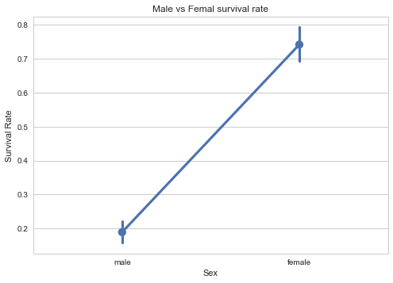

```python
sns.pointplot(x='Sex', y='Survived', data=titanic_df)
plt.ylabel('Survival Rate')
plt.title('Male vs Femal survival rate')
plt.show()
```

#### The previous plot clearly implies that female passenger survival rate is higher than male passengers.

### Calculating percent of survival for each gender.

```python
men_who_survived = filter_passengers('Survived', 'Sex', True, "male")
women_who_survived = filter_passengers('Survived', 'Sex', True, "female")

survival_percentage_male = len(men_who_survived) / \
                          (len(total_male_passengers)*1.0)*100
not_survived_percentage_male = 100 - survival_percentage_male

survival_percentage_female = len(women_who_survived) / \
                            (len(total_female_passengers)*1.0)*100
not_survived_percentage_female = 100 - survival_percentage_female

print('Percentage of males who survived: ',
      float_formatter(survival_percentage_male))
print('Percentage of males who did NOT survive: ',
      float_formatter(not_survived_percentage_male))
print('\nSummary statistics of men who survived\n\n',
      men_who_survived.describe())
print('\nPercentage of females who survived: ',
      float_formatter(survival_percentage_female))
print('Percentage of females who did NOT survive: ',
      float_formatter(not_survived_percentage_female))
print('\nSummary statistics of women who survived\n\n',
      women_who_survived.describe())
```

```
Percentage of males who survived:  18.89
Percentage of males who did NOT survive:  81.11

Summary statistics of men who survived

        PassengerId      Pclass         Age       SibSp       Parch        Fare
count   109.000000  109.000000  109.000000  109.000000  109.000000  109.000000
mean    475.724771    2.018349   27.918593    0.385321    0.357798   40.821484
std     244.717482    0.922774   15.523773    0.636952    0.645826   71.355967
min      18.000000    1.000000    0.420000    0.000000    0.000000    0.000000
25%     272.000000    1.000000   20.000000    0.000000    0.000000    9.500000
50%     508.000000    2.000000   27.000000    0.000000    0.000000   26.287500
75%     680.000000    3.000000   36.000000    1.000000    1.000000   39.000000
max     890.000000    3.000000   80.000000    4.000000    2.000000  512.329200

Percentage of females who survived:  74.20
Percentage of females who did NOT survive:  25.80

Summary statistics of women who survived

        PassengerId      Pclass         Age       SibSp       Parch        Fare
count   233.000000  233.000000  233.000000  233.000000  233.000000  233.000000
mean    429.699571    1.918455   28.307733    0.515021    0.515021   51.938573
std     255.048296    0.834211   13.273216    0.737533    0.820527   64.102256
min       2.000000    1.000000    0.750000    0.000000    0.000000    7.225000
25%     238.000000    1.000000   21.750000    0.000000    0.000000   13.000000
50%     400.000000    2.000000   27.000000    0.000000    0.000000   26.000000
75%     636.000000    3.000000   35.000000    1.000000    1.000000   76.291700
max     888.000000    3.000000   63.000000    4.000000    5.000000  512.329200
```

### Bar graph showing percentage of male and female survivors

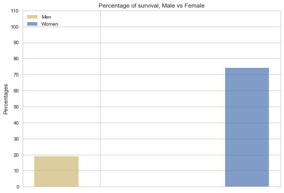

```python
plotbar(survival_percentage_male, survival_percentage_female,
        'Percentage of survival, Male vs Female',
        'y', 'b', np.arange(0, 120, 10), 'Men', 'Women')
```

<p style = "color: #a00">4. What impact if at all does a passenger class has on survival rate?</p>

```python
survival_pclass = titanic_df.groupby(['Pclass', 'Survived'])

total_passengers_upper = titanic_df[titanic_df['Pclass'] == 1]
total_passengers_middle = titanic_df[titanic_df['Pclass'] == 2]
total_passengers_lower = titanic_df[titanic_df['Pclass'] == 3]

survived_passengers_upper = filter_passengers('Survived', 'Pclass', True, 1)
passengers_not_survived_upper = (len(total_passengers_upper) -
                                 len(survived_passengers_upper))
upper_survival_percentage = (len(survived_passengers_upper) /
                             len(total_passengers_upper) * 100)

survived_passengers_middle = filter_passengers('Survived', 'Pclass', True, 2)
passengers_not_survived_middle = (len(total_passengers_middle) -
                                  len(survived_passengers_middle))
middle_survival_percentage = (len(survived_passengers_middle) /
                              len(total_passengers_middle) * 100)

survived_passengers_lower = filter_passengers('Survived', 'Pclass', True, 3)
passengers_not_survived_lower = (len(total_passengers_lower) -
                                 len(survived_passengers_lower))
lower_survival_percentage = (len(survived_passengers_lower) /
                             len(total_passengers_lower) * 100)

print('Upper class passenger info:\n\tTotal:', len(total_passengers_upper))
print('\tSurvived:', len(survived_passengers_upper))
print('\tSurvival percentage:', float_formatter(upper_survival_percentage))
print('\nSummary stats upper class:\n', survived_passengers_upper.describe())

print('\nMiddle class passenger info:\n\tTotal:', len(total_passengers_middle))
print('\tSurvived:', len(survived_passengers_middle))
print('\tSurvival percentage:', float_formatter(middle_survival_percentage))
print('\nSummary stats middle class:\n', survived_passengers_middle.describe())

print('\nLower class passenger info:\n\tTotal:', len(total_passengers_lower))
print('\tSurvived:', len(survived_passengers_lower))
print('\tSurvival percentage:', float_formatter(lower_survival_percentage))
print('\nSummary stats lower class:\n', survived_passengers_lower.describe())
```

```
Upper class passenger info:
	Total: 216
	Survived: 136
	Survival percentage: 62.96

Summary stats upper class:
        PassengerId  Pclass         Age       SibSp       Parch        Fare
count   136.000000   136.0  136.000000  136.000000  136.000000  136.000000
mean    491.772059     1.0   35.535535    0.492647    0.389706   95.608029
std     239.006988     0.0   13.077002    0.632412    0.690387   85.286820
min       2.000000     1.0    0.920000    0.000000    0.000000   25.929200
25%     307.750000     1.0   26.000000    0.000000    0.000000   50.985450
50%     510.500000     1.0   35.000000    0.000000    0.000000   77.958300
75%     693.500000     1.0   43.250000    1.000000    1.000000  111.481225
max     890.000000     1.0   80.000000    3.000000    2.000000  512.329200

Middle class passenger info:
	Total: 184
	Survived: 87
	Survival percentage: 47.28

Summary stats middle class:
        PassengerId  Pclass        Age      SibSp      Parch       Fare
count    87.000000    87.0  87.000000  87.000000  87.000000  87.000000
mean    439.080460     2.0  26.077671   0.494253   0.643678  22.055700
std     244.211937     0.0  14.512693   0.644720   0.820904  10.853502
min      10.000000     2.0   0.670000   0.000000   0.000000  10.500000
25%     254.000000     2.0  18.000000   0.000000   0.000000  13.000000
50%     441.000000     2.0  28.000000   0.000000   0.000000  21.000000
75%     612.500000     2.0  34.000000   1.000000   1.000000  26.250000
max     881.000000     2.0  62.000000   3.000000   3.000000  65.000000

Lower class passenger info:
	Total: 491
	Survived: 119
	Survival percentage: 24.24

Summary stats lower class:
        PassengerId  Pclass         Age       SibSp       Parch        Fare
count   119.000000   119.0  119.000000  119.000000  119.000000  119.000000
mean    394.058824     3.0   21.321330    0.436975    0.420168   13.694887
std     264.680245     0.0   10.239272    0.829934    0.807757   10.692993
min       3.000000     3.0    0.420000    0.000000    0.000000    0.000000
25%     169.500000     3.0   18.000000    0.000000    0.000000    7.775000
50%     359.000000     3.0   21.750000    0.000000    0.000000    8.516700
75%     633.500000     3.0   26.507589    1.000000    1.000000   15.875000
max     876.000000     3.0   63.000000    4.000000    5.000000   56.495800
```

### Plotting passenger survival graph based on class

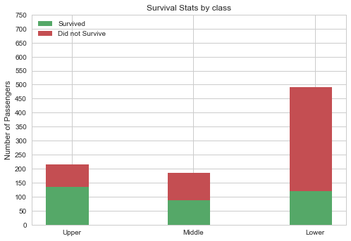

```python
N = 3
survivor_class_means = (len(survived_passengers_upper),
                        len(survived_passengers_middle),
                        len(survived_passengers_lower))
non_survivor_class_means = (passengers_not_survived_upper,
                            passengers_not_survived_middle,
                            passengers_not_survived_lower)

ind = np.arange(N)    # the x locations for the groups
width = 0.35       # the width of the bars: can also be len(x) sequence

p1 = plt.bar(ind, survivor_class_means, width, color='g')
p2 = plt.bar(ind, non_survivor_class_means, width, color='r',
             bottom=survivor_class_means)

plt.ylabel('Number of Passengers')
plt.title('Survival Stats by class')
plt.xticks(ind + width/10., ('Upper', 'Middle', 'Lower'))
plt.yticks(np.arange(0, 800, 50))
plt.legend((p1[0], p2[0]), ('Survived', 'Did not Survive'), loc='upper left')

plt.show()
```

### Note: Questions 3 and 5 will be answered in different sections.

<hr style = "border-width: 5px"/>

## 3. Exploration

In this phase we will look into how survival varies according to one more variable i.e. age. Then we will further explore survival vs 2D data. That is we will further investigate how survival varies according to:

1. Gender and Pclass.
2. Age and Gender.
3. Age and Pclass.

3.How does the survival vary according to age groups?

In order to investigate age vs survival, we will divide age into three groups, viz:

1. Children and youth who are are below 30.
2. Middle aged who are above 29 and below 50
3. Senior passengers who are 50 or above

```python
# Create DataFrame object for each age group for later analysis.
children_n_youth = titanic_df[(titanic_df['Age'] < 30)]
middle_aged = titanic_df[titanic_df['Age'] >= 30][titanic_df['Age'] < 50]
senior_passengers = titanic_df[titanic_df['Age'] >= 50]

not_survived_cny = (children_n_youth['Age'].count() -
                    children_n_youth.Survived.sum())
not_survived_middle = middle_aged['Age'].count() - middle_aged.Survived.sum()
not_survived_seniors = (senior_passengers['Age'].count() -
                        senior_passengers.Survived.sum())

print('Total survivors under 30 years: ', children_n_youth.Survived.sum())
print('\nSummary stats of pasengers age < 30:\n', children_n_youth.describe())

print('\nTotal middle aged survivors: ', middle_aged.Survived.sum())
print('\nSummary stats of middle aged:\n', middle_aged.describe())

print('\nTotal senior survivors: ', senior_passengers.Survived.sum())
print('\nSummary stats of seniors:\n', senior_passengers.describe())
print(not_survived_cny, not_survived_middle, not_survived_seniors)
```

```
Total survivors under 30 years:  192

Summary stats of pasengers age < 30:
        PassengerId      Pclass         Age       SibSp       Parch        Fare
count   522.000000  522.000000  522.000000  522.000000  522.000000  522.000000
mean    434.603448    2.616858   20.737221    0.666667    0.423372   25.439271
std     262.425322    0.669276    7.330890    1.351760    0.750476   38.665912
min       1.000000    1.000000    0.420000    0.000000    0.000000    0.000000
25%     201.250000    2.000000   18.000000    0.000000    0.000000    7.859400
50%     423.500000    3.000000   22.000000    0.000000    0.000000   11.133300
75%     658.500000    3.000000   26.507589    1.000000    1.000000   26.000000
max     890.000000    3.000000   29.000000    8.000000    4.000000  263.000000

Total middle aged survivors:  123

Summary stats of middle aged:
        PassengerId      Pclass         Age       SibSp       Parch        Fare
count   295.000000  295.000000  295.000000  295.000000  295.000000  295.000000
mean    466.247458    1.952542   37.424005    0.332203    0.332203   40.622655
std     251.460150    0.863736    5.496549    0.539097    0.917413   63.366813
min       2.000000    1.000000   30.000000    0.000000    0.000000    0.000000
25%     257.500000    1.000000   33.000000    0.000000    0.000000    8.662500
50%     472.000000    2.000000   36.000000    0.000000    0.000000   24.150000
75%     679.500000    3.000000   41.281386    1.000000    0.000000   50.247900
max     891.000000    3.000000   49.000000    3.000000    6.000000  512.329200

Total senior survivors:  27

Summary stats of seniors:
        PassengerId     Pclass        Age      SibSp      Parch        Fare
count    74.000000  74.000000  74.000000  74.000000  74.000000   74.000000
mean    445.675676   1.554054  57.540541   0.270270   0.283784   46.364415
std     242.330133   0.742854   6.767042   0.504698   0.692826   49.480722
min       7.000000   1.000000  50.000000   0.000000   0.000000    6.237500
25%     250.750000   1.000000  52.000000   0.000000   0.000000   12.643750
50%     483.500000   1.000000  56.000000   0.000000   0.000000   27.631250
75%     631.750000   2.000000  61.750000   0.000000   0.000000   68.744800
max     880.000000   3.000000  80.000000   2.000000   4.000000  263.000000
330 172 47
```

### Age vs Survival Plot

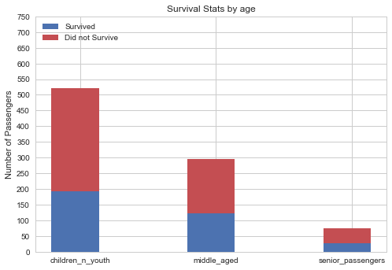

```python
N = 3
survivor_age_means = (children_n_youth.Survived.sum(),
                      middle_aged.Survived.sum(),
                      senior_passengers.Survived.sum())
non_survivor_age_means = (not_survived_cny,
                          not_survived_middle, not_survived_seniors)

ind = np.arange(N)    # the x locations for the groups
width = 0.35       # the width of the bars: can also be len(x) sequence

p1 = plt.bar(ind, survivor_age_means, width, color='b')
p2 = plt.bar(ind, non_survivor_age_means, width, color='r',
             bottom=survivor_age_means)

plt.ylabel('Number of Passengers')
plt.title('Survival Stats by age')
plt.xticks(ind + width/10., ('children_n_youth', 'middle_aged',
                             'senior_passengers'))
plt.yticks(np.arange(0, 800, 50))
plt.legend((p1[0], p2[0]), ('Survived', 'Did not Survive'), loc='upper left')

plt.show()
```

**Inference:** Numbers indicate that children and youth who survived is greater than middle aged passengers and senior passengers. Also number of senior passengers who survived is low. But the plot of **age vs survival** indicates that total number of children and youth > middle aged > senior passengers. The graph also shows that number of passengers under 30 years who did not survive is far greater than that of middle aged and seniors (The reason being, total number of children and youth aboard the ship is much higher.).

1. Total number of people under 30 years of age who survived = 192
2. Average age of children and youth = 20.74
3. Total number of middle aged people who survived = 123
4. Average age of middle aged passengers = 37.42
5. Total number of senior people who survived = 27
6. Average age of senior passengers = 57.54

### Exploring survival rate using 2D data.

```python
gender_n_class = titanic_df.groupby(['Sex', 'Pclass'])
print(gender_n_class['Survived'].describe())
```

```
              count unique    top freq
Sex    Pclass
female 1         94      2   True   91
       2         76      2   True   70
       3        144      2   True   72
male   1        122      2  False   77
       2        108      2  False   91
       3        347      2  False  300
```

**Inference:**

1. Survival percent is really high among females in upper and middle clases.
2. Survival percent is exactly 50 in lower class for females
3. Survival percent as compared to females is very low in all three classes for males.
4. Among males of all the three classes, survival percent is high for upper class.

### Investigating relationship between survival rate based on age and gender.

```python
male_children_n_youth = children_n_youth[children_n_youth['Sex'] == 'male']
male_middle_aged = middle_aged[middle_aged['Sex'] == 'male']
male_seniors = senior_passengers[senior_passengers['Sex'] == 'male']

female_children_n_youth = children_n_youth[children_n_youth['Sex'] == 'female']
female_middle_aged = middle_aged[middle_aged['Sex'] == 'female']
female_seniors = senior_passengers[senior_passengers['Sex'] == 'female']

survived_male_cny = male_children_n_youth[male_children_n_youth['Survived'] == True]
survived_male_middle_aged = male_middle_aged[male_middle_aged['Survived'] == True]
survived_male_seniors = male_seniors[male_seniors['Survived'] == True]

survived_female_cny = female_children_n_youth[female_children_n_youth['Survived'] == True]
survived_female_middle_aged = female_middle_aged[female_middle_aged['Survived'] == True]
survived_female_seniors = female_seniors[female_seniors['Survived'] == True]

percent_male_survived_cny = len(survived_male_cny) / len(male_children_n_youth) * 100
percent_male_survived_middle = len(survived_male_middle_aged) / len(male_middle_aged) * 100
percent_male_survived_seniors = len(survived_male_seniors) / len(male_seniors)

percent_female_survived_cny = len(survived_female_cny) / len(female_children_n_youth) * 100
percent_female_survived_middle = len(survived_female_middle_aged) / len(female_middle_aged) * 100
percent_female_survived_seniors = len(survived_female_seniors) / len(female_seniors)

print('Percent male and female who survived and were children & youth:',
     float_formatter(percent_male_survived_cny), '&',float_formatter(percent_female_survived_cny))
print('Percent male and female who survived and were middle aged:',
     float_formatter(percent_male_survived_middle), '&',
      float_formatter(percent_female_survived_middle))
print('Percent male and female who survived and were serniors:',
     float_formatter(percent_male_survived_seniors), '&',
      float_formatter(percent_female_survived_seniors))

print('\nMean age of males who survived among children and youth: ',
      survived_male_cny['Age'].mean())
print('Max age amongst males who survived in children and youth: ',
      survived_male_cny['Age'].max())
print('Mean age of males who survived among middle aged: ',
      survived_male_middle_aged['Age'].mean())
print('Max age amongst males who survived among middle aged: ',
      survived_male_middle_aged['Age'].max())
print('Mean age of males who survived among seniors: ',
      survived_male_seniors['Age'].mean())
print('Max age amongst males who survived among middle aged: ',
      survived_male_seniors['Age'].max())

print('\nMean age of females who survived among children and youth: ',
      survived_female_cny['Age'].mean())
print('Max age amongst females who survived in children and youth: ',
      survived_female_cny['Age'].max())
print('Mean age of females who survived among middle aged: ',
      survived_female_middle_aged['Age'].mean())
print('Max age amongst females who survived among middle aged: ',
      survived_female_middle_aged['Age'].max())
print('Mean age of females who survived among seniors: ',
      survived_female_seniors['Age'].mean())
print('Max age amongst females who survived among middle aged: ',
      survived_female_seniors['Age'].max())
```

```
Percent male and female who survived and were children & youth: 18.13 & 69.11
Percent male and female who survived and were middle aged: 21.65 & 80.20
Percent male and female who survived and were serniors: 0.13 & 0.91

Mean age of males who survived among children and youth:  17.403971673254283
Max age amongst males who survived in children and youth:  29.0
Mean age of males who survived among middle aged:  37.80686535320199
Max age amongst males who survived among middle aged:  49.0
Mean age of males who survived among seniors:  58.714285714285715
Max age amongst males who survived among middle aged:  80.0

Mean age of females who survived among children and youth:  19.111332923832922
Max age amongst females who survived in children and youth:  29.0
Mean age of females who survived among middle aged:  36.66673928830791
Max age amongst females who survived among middle aged:  49.0
Mean age of females who survived among seniors:  55.15
Max age amongst females who survived among middle aged:  63.0
```

### Age and Gender vs Survival percentage

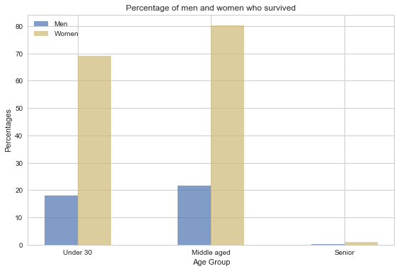

```python
N = 3

survived_means_men = (percent_male_survived_cny,
                      percent_male_survived_middle,
                      percent_male_survived_seniors)

survived_means_women = (percent_female_survived_cny,
                        percent_female_survived_middle,
                        percent_female_survived_seniors)


fig, ax = plt.subplots()

index = np.arange(N)
bar_width = 0.25

opacity = 0.7
error_config = {'ecolor': '0.3'}

rects1 = plt.bar(index, survived_means_men, bar_width,
                 alpha=opacity,
                 color='b',
                 yerr=0,
                 error_kw=error_config,
                 label='Men')

rects2 = plt.bar(index + bar_width, survived_means_women, bar_width,
                 alpha=opacity,
                 color='y',
                 yerr=0,
                 error_kw=error_config,
                 label='Women')

plt.xlabel('Age Group')
plt.ylabel('Percentages')
plt.title('Percentage of men and women who survived')
plt.xticks(index + bar_width/2., ('Under 30', 'Middle aged', 'Senior'))
plt.legend(loc='upper left')

plt.tight_layout()
plt.show()
```

**Some general statistics:**

1. Mean age of males under 30 years is less than that of females.
2. In the under 30 years group max age of male is same as that of female group.
3. Mean age of males in the middle aged group is greater than that of females. (The difference in age is negligible though.)
4. In the middle aged group max age of male is same as that of female group.

Similar stats can be stated about senior pasengers group.

```python
# Helper method to create a histogram of given data.
def create_hist(data, title):
    plt.hist(data)
    plt.xlabel('Age distribution')
    plt.ylabel('Frequency')
    plt.title(title)
    plt.show()
```

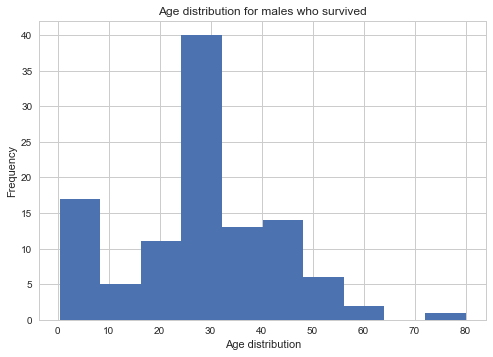

[figure not shown]

```python
total_males = titanic_df[titanic_df['Sex'] == 'male']
survived_males = total_males[total_males['Survived'] == True]

total_females = titanic_df[titanic_df['Sex'] == 'male']
survived_females = total_males[total_males['Survived'] == True]

create_hist(survived_males['Age'], 'Age distribution for males who survived')
create_hist(survived_females['Age'],
            'Age distribution of females who survived')
```

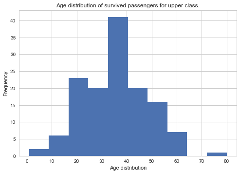

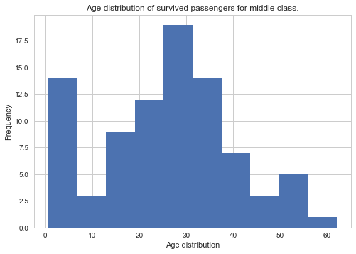

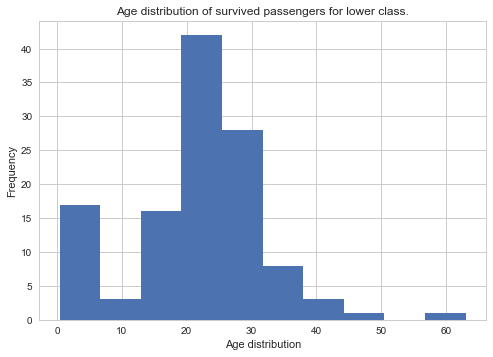

```python
upper_class_survived = filter_passengers('Pclass', 'Survived', 1, True)
middle_class_survived = filter_passengers('Pclass', 'Survived', 2, True)
lower_class_survived = filter_passengers('Pclass', 'Survived', 3, True)

create_hist(upper_class_survived['Age'],
            'Age distribution of survived passengers for upper class.')
create_hist(middle_class_survived['Age'],
            'Age distribution of survived passengers for middle class.')
create_hist(lower_class_survived['Age'],
            'Age distribution of survived passengers for lower class.')
```

**Inferences made from histograms:**

1. Upper class: Survival chances are really good if passenger's age is > 18 and less than 50.
2. Middle class: If the passenger's age is less than 40 then survival chances are high.
3. In middle class one more interesting thing to observer is, survival is really high for age bin 1 to 6. (just a rough estimation.)
4. Lower class: Survival chances are good for age group 15 to 30.

## Correlation

### Pearson's r for pclass and survival

```python
corr = titanic_df.corr()
print(corr['Survived'])

pclass_titanic = titanic_df['Pclass']
titanic_survived = titanic_df['Survived']
scipy.stats.pearsonr(pclass_titanic.get_values(),
                     titanic_survived.get_values())
```

```
PassengerId   -0.005007
Survived       1.000000
Pclass        -0.338481
Age           -0.067485
SibSp         -0.035322
Parch          0.081629
Fare           0.257307
Name: Survived, dtype: float64
```

```
(-0.33848103596101536, 2.5370473879804202e-25)
```

**r = -0.34** (rounded to two decimal places.)  
Documentation for <a href = "https://docs.scipy.org/doc/scipy/reference/generated/scipy.stats.pearsonr.html" style = "text-decoration: none">pearson's r</a> states: Like other correlation coefficients, this one varies between -1 and +1 with 0 implying no correlation. Correlations of -1 or +1 imply an exact linear relationship. Positive correlations imply that as x increases, so does y. Negative correlations imply that as x increases, y decreases.

**Inference:** r is negative for x representing passenger class and y representing survived column. Higher the class number lower is the chance of survival. We should be careful here to note that higher class number means in descending order (3 = lower, 2 = middle and 1 = upper). This result is in agreement with our analysis of relationship between class and survival in **Revisiting the Questions** section.

<hr style = "border-width: 5px"/>

## 4. Conclusion

All statistical concclusions are explained within the *Inference* part of each section.  
**Summary:**

- The entire analysis and exploration was mainly about survival of passengers aboard Titanic ship.
- There are other things we could have investigated independently such as passenger demographics viz, gender, age and class.
- But demographics alone is'nt much useful for practical insights into the data.
- Hence within the analysis process the main factor we were interested was survival of each pasenger.
- All demographics were related to survival rate and explored from different angles.

**Limitations** in the data:

1. The data wrangling phase showed that there were large gaps in data, specially when it came to the age of passengers.
2. Two embarkation ports were missing.

There are other limitations on the data such as:

1. Whether lurking variables were constant or kept consistent. Example availability of life boats.
2. The impact of size of sample data.
3. One more categorization that could have been included in the data was whether person was a crew or passenger.

Because of the afore mentioned limitations posed by data, **all results and inference are tentative only.**

<hr style = 'border-width: 5px' />